# Prueba de uniformidad

Prueba de uniformidad Un método simple para verificar si los números son uniformes es crear un histograma de los datos y ver si el histograma es razonablemente plano. Ya vimos cómo evaluar esto, pero vamos a verificar si `runif` funciona bien. Los histogramas simples se pueden crear en R usando `hist` (o si lo prefieres, puedes usar `ggplot`).

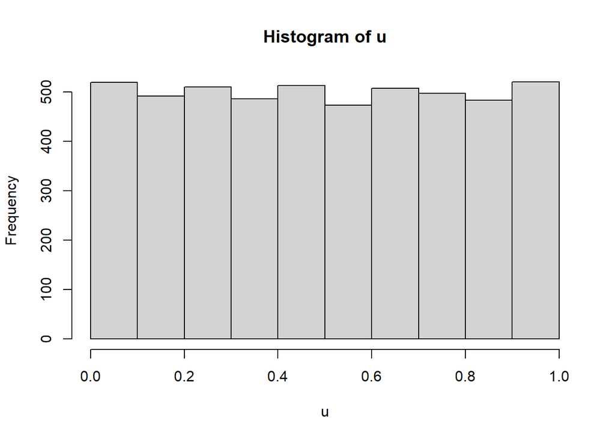

```r
set.seed(1984)
u <- runif(5000)
hist(u)
```

```r
u1<-runif(10, min = 0, max = 1)
u2<-runif(5, min = 0, max = 1)
```

Podemos ver que el histograma es razonablemente plano y, por lo tanto, la suposición de uniformidad parece sostenerse.

Aunque el histograma es bastante informativo, no es un método formalmente riguroso. Por otro lado, podríamos considerar pruebas de hipótesis de esta forma:

- $H_0$: $u_i$ es uniforme entre cero y uno, $i=1,2,…$
- $H_a$: $u_i$ no es uniforme entre cero y uno, $i=1,2,…$

La hipótesis nula es, por lo tanto, que los números son efectivamente uniformes, mientras que la alternativa sostiene que los números no lo son. Si rechazamos la hipótesis nula, lo cual ocurre si el valor p de la prueba es muy pequeño (o menor que un valor crítico α de nuestra elección), entonces creeríamos que la secuencia de números no es uniforme.

Hay varias maneras de llevar a cabo tal prueba, pero aquí consideraremos solo una: la llamada Prueba de Kolmogorov-Smirnov.

Para entender cómo funciona la prueba, necesitamos introducir brevemente el concepto de función de distribución acumulada empírica o ecdf. La fdae $\hat{F}$ es la función de distribución acumulativa calculada a partir de una secuencia de $N$ números como

$$\begin{equation}
\hat{F}=\frac{\text{números en la secuencia}}{N} \le t
\end{equation}$$

Consideremos el siguiente ejemplo.

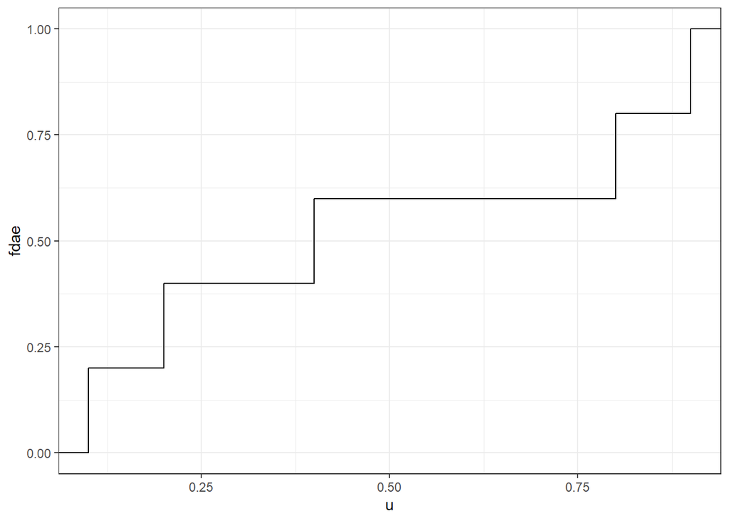

```r
data <- data.frame(u= c(0.1,0.2,0.4,0.8,0.9))
ggplot(data, aes(u)) + stat_ecdf(geom = "step") + theme_bw() + ylab("fdae")
```

Por ejemplo, dado que hay 3 números de 5 en el vector u que son menores que 0.7, entonces $\hat{F}(0.7) = \frac{3}{5}.$

La idea detrás de la prueba de Kolmogorov-Smirnov es cuantificar qué tan similar es la fdae calculada a partir de una secuencia de datos a la de una distribución uniforme, la cual está representada por una línea recta. La prueba de Kolmogorov-Smirnov formaliza esta idea de similitud entre la fdae y la fda de la uniforme en una prueba de hipótesis. La función ks.test implementa esta prueba en R.

```r
ks.test(u1, "punif")
```

```
##
##  Exact one-sample Kolmogorov-Smirnov test
##
## data:  u1
## D = 0.38719, p-value = 0.07363
## alternative hypothesis: two-sided
```

```r
ks.test(u2, "punif")
```

```
##
##  Exact one-sample Kolmogorov-Smirnov test
##
## data:  u2
## D = 0.33014, p-value = 0.5452
## alternative hypothesis: two-sided
```